DS 6030 | Fall 2024 | University of Virginia

# Homework #5: Probability and Classification

Author

Published

October 9, 2024

# Required R packages and Directories

```r
dir_data= 'https://mdporter.github.io/teaching/data/' # data directory
library(glmnet)
library(tidyverse) # functions for data manipulation
```

# Crime Linkage

Crime linkage attempts to determine if a set of unsolved crimes share a common offender. *Pairwise* crime linkage is the more simple task of deciding if two crimes share a common offender; it can be considered a binary classification problem. The linkage training data has 8 evidence variables that measure the similarity between a pair of crimes:

- `spatial` is the spatial distance between the crimes
- `temporal` is the fractional time (in days) between the crimes
- `tod` and `dow` are the differences in time of day and day of week between the crimes
- `LOC`, `POA,` and `MOA` are binary with a 1 corresponding to a match (type of property, point of entry, method of entry)
- `TIMERANGE` is the time between the earliest and latest possible times the crime could have occurred (because the victim was away from the house during the crime).
- The response variable indicates if the crimes are linked ($y=1$) or unlinked ($y=0$).

These problems use the [linkage-train](https://mdporter.github.io/teaching/data//linkage_train.csv) and [linkage-test](https://mdporter.github.io/teaching/data//linkage_test.csv) datasets (click on links for data).

## Load Crime Linkage Data

**Solution**

```r
train_data <- read.csv(file.path(dir_data, "linkage_train.csv"))
```

# Problem 1: Penalized Regression for Crime Linkage

## a. Fit a penalized *linear regression* model to predict linkage.

Use an elastic net penalty (including lasso and ridge) (your choice).

- Report the value of $\alpha \in [0, 1]$ used.
- Report the value of $\lambda$ used.
- Report the estimated coefficients.

**Solution**

```r
y <- train_data$y
x <- as.matrix(train_data %>% select(-c("y")))

alpha_values <- seq(0, 1, by = 0.1)

results <- list(alpha = c(), lambda = c(), cv_error = c())

for (alpha in alpha_values) {
  cv_model <- cv.glmnet(x, y, alpha = alpha, seed = 27)

  lambda_min <- cv_model$lambda.min
  cv_error <- min(cv_model$cvm)  # Get the minimum CV error

  results$alpha <- c(results$alpha, alpha)
  results$lambda <- c(results$lambda, lambda_min)
  results$cv_error <- c(results$cv_error, cv_error)
}

min_index <- which.min(results$cv_error)

best_alpha <- results$alpha[min_index]
best_lambda <- results$lambda[min_index]
best_cv <- results$cv_error[min_index]

linear_model <- glmnet(x, y, alpha = best_alpha, lambda = best_lambda)

cat("Best alpha:", best_alpha, "\n")
```

```
Best alpha: 0.9
```

```r
cat("Best lambda:", best_lambda, "\n")
```

```
Best lambda: 9.74e-05
```

```r
cat("Best cross-validation error:", best_cv, "\n")
```

```
Best cross-validation error: 0.0152
```

```r
cat("Coefficients:\n")
```

```
Coefficients:
```

```r
print(coef(linear_model))
```

```
9 x 1 sparse Matrix of class "dgCMatrix"
                   s0
(Intercept)  0.093471
spatial     -0.002350
temporal    -0.000157
tod         -0.002219
dow         -0.005802
LOC          0.043121
POA          0.009282
MOA          0.007174
TIMERANGE    0.000025
```

## b. Fit a penalized *logistic regression* model to predict linkage.

Use an elastic net penalty (including lasso and ridge) (your choice).

- Report the value of $\alpha \in [0, 1]$ used.
- Report the value of $\lambda$ used.
- Report the estimated coefficients.

**Solution**

```r
y <- train_data$y
x <- as.matrix(train_data %>% select(-c("y")))

alpha_values <- seq(0, 1, by = 0.1)

results <- list(alpha = c(), lambda = c(), cv_error = c())

for (alpha in alpha_values) {
  cv_model <- cv.glmnet(x, y, alpha = alpha, family = "binomial")

  lambda_min <- cv_model$lambda.min
  cv_error <- min(cv_model$cvm)

  results$alpha <- c(results$alpha, alpha)
  results$lambda <- c(results$lambda, lambda_min)
  results$cv_error <- c(results$cv_error, cv_error)
}

min_index <- which.min(results$cv_error)

best_alpha <- results$alpha[min_index]
best_lambda <- results$lambda[min_index]
best_cv <- results$cv_error[min_index]

logistic_model <- glmnet(x, y, alpha = best_alpha, lambda = best_lambda, family = "binomial")

cat("Best alpha:", best_alpha, "\n")
```

```
Best alpha: 0.6
```

```r
cat("Best lambda:", best_lambda, "\n")
```

```
Best lambda: 6.94e-05
```

```r
cat("Best cross-validation error:", best_cv, "\n")
```

```
Best cross-validation error: 0.0919
```

```r
cat("Coefficients:\n")
```

```
Coefficients:
```

```r
print(coef(logistic_model))
```

```
9 x 1 sparse Matrix of class "dgCMatrix"
                   s0
(Intercept) -0.036329
spatial     -0.284806
temporal    -0.012416
tod         -0.113005
dow         -0.239519
LOC          1.388311
POA          0.440915
MOA          0.211007
TIMERANGE    0.000614
```

# Problem 2: Random Forest for Crime Linkage

Fit a random forest model to predict crime linkage.

- Report the loss function (or splitting rule) used.
- Report any non-default tuning parameters.
- Report the variable importance (indicate which importance method was used).

**Solution**

```r
library(ranger)
y <- train_data$y
x <- train_data %>% select(-y)

mtry_values <- seq(1, ncol(x), by = 1)
results <- list(mtry = c(), oob_error = c())

for (mtry in mtry_values) {
  rf_model <- ranger(
    formula = y ~ .,
    data = train_data,
    importance = "impurity",
    num.trees = 1000,
    mtry = mtry,
    splitrule = "gini",
    classification = TRUE,
    oob.error = TRUE,
    seed = 27
  )

  results$mtry <- c(results$mtry, mtry)
  results$oob_error <- c(results$oob_error, rf_model$prediction.error)  # OOB error

}

results_df <- as.data.frame(results)

best_mtry_index <- which.min(results_df$oob_error)
best_mtry <- results_df$mtry[best_mtry_index]
best_oob_error <- results_df$oob_error[best_mtry_index]

cat("Best mtry:", best_mtry, "\n")
```

```
Best mtry: 3
```

```r
cat("Best OOB error:", best_oob_error, "\n")
```

```
Best OOB error: 0.0096
```

```r
final_rf_model <- ranger(
  formula = y ~ .,
  data = train_data,
  importance = "impurity",
  num.trees = 1000,
  mtry = best_mtry,
  splitrule = "gini",
  classification = TRUE,
  probability = TRUE,
  seed = 27
)

var_importance <- final_rf_model$variable.importance

cat("Variable Importance (Mean Decrease in Gin was used):", "\n")
```

```
Variable Importance (Mean Decrease in Gin was used):
```

```r
print(var_importance)
```

```
  spatial  temporal       tod       dow       LOC       POA       MOA TIMERANGE
   406.36    202.78     77.46     74.18     19.82      6.05      4.97     58.63
```

# Problem 3: ROC Curves

## a. ROC curve: training data

Produce one plot that has the ROC curves, using the *training data*, for all three models (linear, logistic, and random forest). Use color and/or linetype to distinguish between models and include a legend.  
Also report the AUC (area under the ROC curve) for each model. Again, use the *training data*.

- Note: you should be weary of being asked to evaluation predictive performance from the same data used to estimate the tuning and model parameters. The next problem will walk you through a more proper way of evaluating predictive performance with resampling.

**Solution**

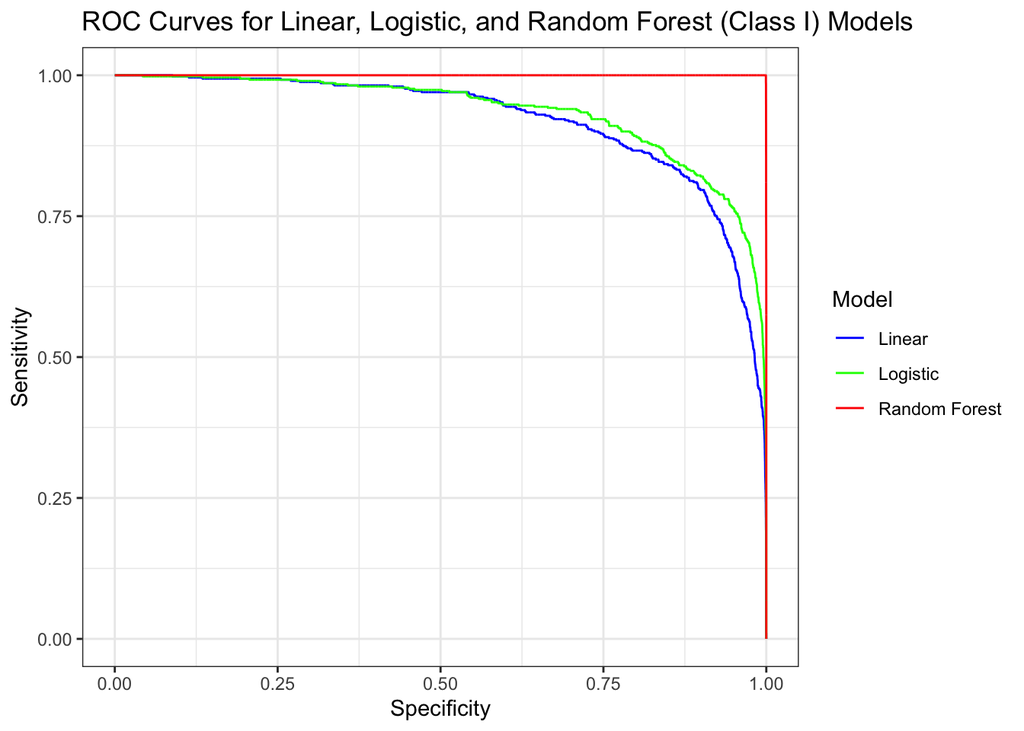

```r
library(pROC)
y <- train_data$y
x <- as.matrix(train_data %>% select(-c("y")))

pred_linear <- predict(linear_model, newx = x, type = "response")
roc_linear <- roc(train_data$y, as.vector(pred_linear))
auc_linear <- auc(roc_linear)

pred_logistic <- predict(logistic_model, newx = x, type = "response")
roc_logistic <- roc(train_data$y, as.vector(pred_logistic))
auc_logistic <- auc(roc_logistic)

pred_rf <- predict(final_rf_model, data = train_data)$predictions[,2]
roc_rf <- roc(train_data$y, pred_rf)
auc_rf <- auc(roc_rf)

ggplot() +
  geom_line(aes(x = roc_linear$specificities, y = roc_linear$sensitivities, color = "Linear")) +
  geom_line(aes(x = roc_logistic$specificities, y = roc_logistic$sensitivities, color = "Logistic")) +
  geom_line(aes(x = roc_rf$specificities, y = roc_rf$sensitivities, color = "Random Forest")) +
  labs(title = "ROC Curves for Linear, Logistic, and Random Forest (Class I) Models",
       x = "Specificity",
       y = "Sensitivity") +
  scale_color_manual(name = "Model", values = c("Linear" = "blue", "Logistic" = "green", "Random Forest" = "red"))
```

```r
cat("AUC for Linear Model:", auc_linear, "\n")
```

```
AUC for Linear Model: 0.921
```

```r
cat("AUC for Logistic Model:", auc_logistic, "\n")
```

```
AUC for Logistic Model: 0.935
```

```r
cat("AUC for Random Forest Model:", auc_rf, "\n")
```

```
AUC for Random Forest Model: 1
```

## b. ROC curve: resampling estimate

Recreate the ROC curve from the penalized logistic regression (logreg) and random forest (rf) models using repeated hold-out data. The following steps will guide you:

- For logreg, use $\alpha=.75$. For rf use *mtry = 2*, *num.trees = 1000*, and fix any other tuning parameters at your choice.
- Run the following steps 25 times:
  1. Hold out 500 observations.
  2. Use the remaining observations to estimate $\lambda$ using 10-fold CV for the logreg model. Don’t tune any rf parameters.
  3. Predict the probability of linkage for the 500 hold-out observations.
  4. Store the predictions and hold-out labels.
  5. Calculate the AUC.
- Report the mean AUC and standard error for both models. Compare to the results from part a.
- Produce two plots showing the 25 ROC curves for each model.
- Note: by estimating $\lambda$ each iteration, we are incorporating the uncertainty present in estimating that tuning parameter.

**Solution**

```r
set.seed(27)

n_iterations <- 25
holdout_size <- 500
alpha_value <- 0.75
mtry_value <- 2
num_trees <- 1000

results_logreg <- list(auc = c(), roc_curves = list())
results_rf <- list(auc = c(), roc_curves = list())

for (i in 1:n_iterations) {
  # i: Hold out 500 observations
  holdout_index <- sample(1:nrow(train_data), holdout_size)
  train_subset <- train_data[-holdout_index, ]
  holdout_subset <- train_data[holdout_index, ]

  y_train <- train_subset$y
  x_train <- as.matrix(train_subset %>% select(-c("y")))

  # ii: Estimate lambda using 10-fold CV for logistic regression
  cv_logreg <- cv.glmnet(x_train, y_train, alpha = alpha_value, family = "binomial", nfolds = 10)
  best_lambda <- cv_logreg$lambda.min
  logreg_model <- glmnet(x_train, y_train, alpha = alpha_value, lambda = best_lambda, family = "binomial")

  # iii: Predict the probability for the hold-out observations
  x_holdout <- as.matrix(holdout_subset %>% select(-c("y")))
  pred_logreg <- predict(logreg_model, newx = x_holdout, type = "response")

  # random forest model
  rf_model <- ranger(
    formula = y ~ .,
    data = train_subset,
    mtry = mtry_value,
    num.trees = num_trees,
    probability = TRUE,
    seed = 27
  )
  pred_rf <- predict(rf_model, data = holdout_subset)$predictions[,2]

  # iv: Calculate the AUC for both models
  auc_logreg <- auc(roc(holdout_subset$y, as.vector(pred_logreg)))
  auc_rf <- auc(roc(holdout_subset$y, pred_rf))

  results_logreg$auc <- c(results_logreg$auc, auc_logreg)
  results_rf$auc <- c(results_rf$auc, auc_rf)

  results_logreg$roc_curves[[i]] <- roc(holdout_subset$y, as.vector(pred_logreg))
  results_rf$roc_curves[[i]] <- roc(holdout_subset$y, pred_rf)
}
# v: mean AUC and standard error for both models
mean_auc_logreg <- mean(results_logreg$auc)
se_auc_logreg <- sd(results_logreg$auc) / sqrt(n_iterations)

mean_auc_rf <- mean(results_rf$auc)
se_auc_rf <- sd(results_rf$auc) / sqrt(n_iterations)

cat("Logistic Regression:", mean_auc_logreg, "SE:", se_auc_logreg, "\n")
```

```
Logistic Regression: 0.919 SE: 0.00941
```

```r
cat("Random Forest:", mean_auc_rf, "SE:", se_auc_rf, "\n")
```

```
Random Forest: 0.913 SE: 0.0131
```

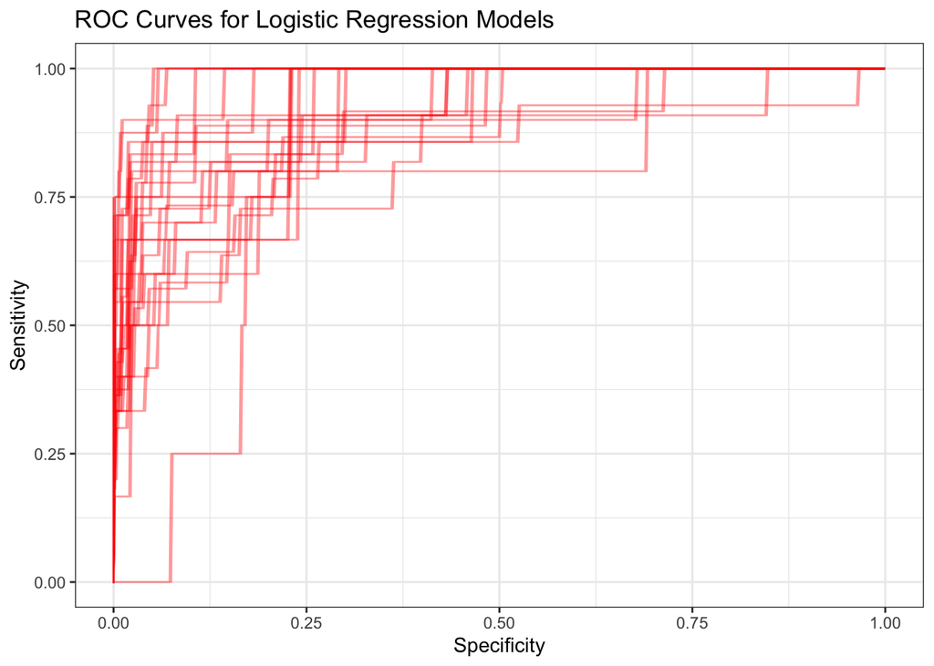

```r
# Logistic Regression
ggplot() +
  lapply(1:n_iterations, function(i) {
    geom_line(aes(x = 1 - results_logreg$roc_curves[[i]]$specificities,
                  y = results_logreg$roc_curves[[i]]$sensitivities),
              color = "red", alpha = 0.4)
  }) +
  labs(title = "ROC Curves for Logistic Regression Models",
       x = "Specificity", y = "Sensitivity")
```

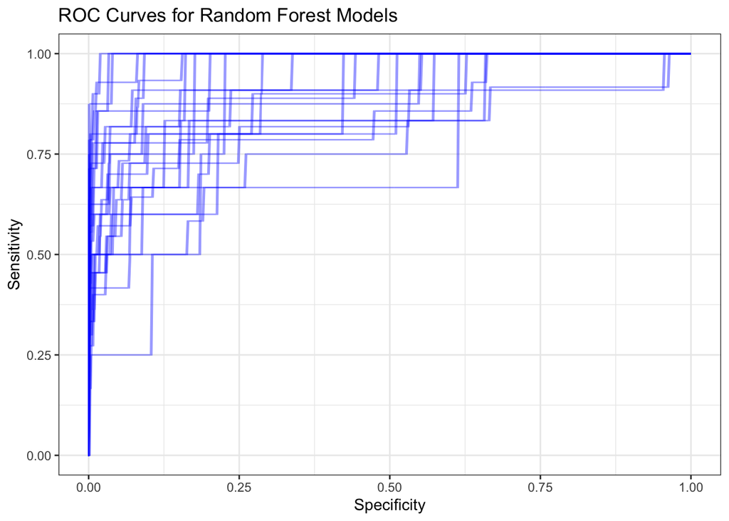

```r
# Random Forest
ggplot() +
  lapply(1:n_iterations, function(i) {
    geom_line(aes(x = 1 - results_rf$roc_curves[[i]]$specificities,
                  y = results_rf$roc_curves[[i]]$sensitivities),
              color = "blue", alpha = 0.4)
  }) +
  labs(title = "ROC Curves for Random Forest Models",
       x = "Specificity", y = "Sensitivity")
```

# Problem 4: Contest

## a. Contest Part 1: Predict the estimated *probability* of linkage.

Predict the estimated *probability* of linkage for the test data (using any model).

- Submit a .csv file (ensure comma separated format) named `lastname_firstname_1.csv` that includes the column named **p** that is your estimated posterior probability. We will use automated evaluation, so the format must be exact.
- You are free to any model (even ones we haven’t yet covered in the course).
- You are free to use any data transformation or feature engineering.
- You will receive credit for a proper submission; the top five scores will receive 2 bonus points.
- Your probabilities will be evaluated with respect to the mean negative Bernoulli log-likelihood (known as the average *log-loss* metric):
  $$L = - \frac{1}{M} \sum_{i=1}^m [y_i \log \, \hat{p}_i + (1 - y_i) \log \, (1 - \hat{p}_i)]$$
  where $M$ is the number of test observations, $\hat{p}_i$ is the prediction for the $i$th test observation, and $y_i \in \{0,1\}$ are the true test set labels.

**Solution**

```r
test_data <- read.csv(file.path(dir_data, "linkage_test.csv"))
x_test <- test_data

pred_prob_rf <- predict(final_rf_model, data = x_test)$predictions[,2]

write.csv(data.frame(p = pred_prob_rf), "yang_alex_1.csv", row.names = FALSE)
```

## b. Contest Part 2: Predict the *linkage label*.

Predict the linkages for the test data (using any model).

- Submit a .csv file (ensure comma separated format) named `lastname_firstname_2.csv` that includes the column named **linkage** that takes the value of 1 for linked pairs and 0 for unlinked pairs. We will use automated evaluation, so the format must be exact.
- You are free to any model (even ones we haven’t yet covered in the course).
- You are free to use any data transformation or feature engineering.
- Your labels will be evaluated based on total cost, where cost is equal to `1*FP + 8*FN`. This implies that False Negatives (FN) are 8 times as costly as False Positives (FP).
- You will receive credit for a proper submission; the top five scores will receive 2 bonus points. Note: you only will get bonus credit for one of the two contests.

**Solution**

```r
pred_prob_rf <- predict(final_rf_model, data = x_test)$predictions[,2]
threshold <- 0.3
pred_linkage <- ifelse(pred_prob_rf > threshold, 1, 0)

write.csv(data.frame(linkage = pred_linkage), "yang_alex_2.csv", row.names = FALSE)
```